# `tabula-rasa/py/plt/plt.ipynb`

My solutions for /11_mod_matplotlib/17-Exercises.ipynb

## 🐍 Python imports 🐍

```python
import os

import matplotlib.pyplot as plt

plt.style.use("./style/ai.mplstyle")

import numpy as np
import pandas as pd
```

## 📁 Data loading 📁

```python
path = os.path.join(".", "data", "company_sales_data.csv")
df = pd.read_csv(path)
df
```

|  | month_number | facecream | facewash | toothpaste | bathingsoap | shampoo | moisturizer | total_units | total_profit |
| --- | --- | --- | --- | --- | --- | --- | --- | --- | --- |
| 0 | 1 | 2500 | 1500 | 5200 | 9200 | 1200 | 1500 | 21100 | 211000 |
| 1 | 2 | 2630 | 1200 | 5100 | 6100 | 2100 | 1200 | 18330 | 183300 |
| 2 | 3 | 2140 | 1340 | 4550 | 9550 | 3550 | 1340 | 22470 | 224700 |
| 3 | 4 | 3400 | 1130 | 5870 | 8870 | 1870 | 1130 | 22270 | 222700 |
| 4 | 5 | 3600 | 1740 | 4560 | 7760 | 1560 | 1740 | 20960 | 209600 |
| 5 | 6 | 2760 | 1555 | 4890 | 7490 | 1890 | 1555 | 20140 | 201400 |
| 6 | 7 | 2980 | 1120 | 4780 | 8980 | 1780 | 1120 | 29550 | 295500 |
| 7 | 8 | 3700 | 1400 | 5860 | 9960 | 2860 | 1400 | 36140 | 361400 |
| 8 | 9 | 3540 | 1780 | 6100 | 8100 | 2100 | 1780 | 23400 | 234000 |
| 9 | 10 | 1990 | 1890 | 8300 | 10300 | 2300 | 1890 | 26670 | 266700 |
| 10 | 11 | 2340 | 2100 | 7300 | 13300 | 2400 | 2100 | 41280 | 412800 |
| 11 | 12 | 2900 | 1760 | 7400 | 14400 | 1800 | 1760 | 30020 | 300200 |

## ❄ Exercise 1.

Read Total profit of all months and show it using a line plot

Total profit data provided for each month. Generated line plot must include the following properties:

1. X label name = Month Number
2. Y label name = Total profit

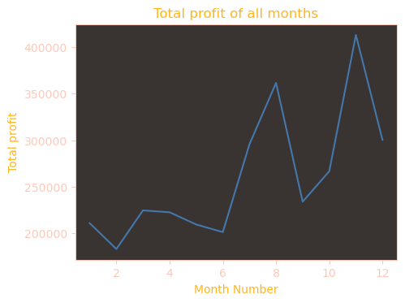

```python
plt.figure(figsize=[5.12, 3.84], dpi=100)

plt.plot(df["month_number"], df["total_profit"])

plt.title("Total profit of all months")
plt.xlabel("Month Number")
plt.ylabel("Total profit")

plt.show()
```

## 🌸 Exercise 2.

Get Total profit of all months and show line plot with the following Style properties

Generated line plot must include following Style properties:

1. Line Style dotted and Line-color should be red
2. Show legend at the lower right location.
3. X label name = Month Number
4. Y label name = Sold units number
5. Add a circle marker.
6. Line marker color as read
7. Line width should be 3

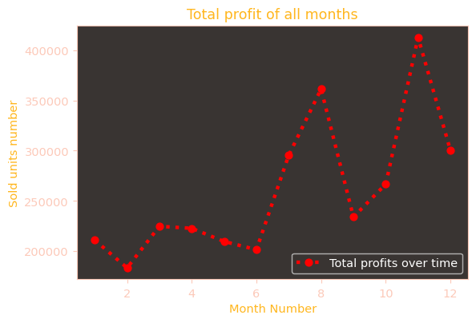

```python
plt.figure(figsize=[6, 4], dpi=105)

plt.plot(
    df["month_number"],
    df["total_profit"],
    ls=":",
    c="red",
    marker="o",
    lw=3,
    label="Total profits over time",
)

plt.title("Total profit of all months")
plt.xlabel("Month Number")
plt.ylabel("Sold units number")

plt.legend(loc="lower right")

plt.show()
```

## ❄ Exercise 3.

Read all product sales data and show it using a multiline plot

Display the number of units sold per month for each product using multiline plots. (i.e., Separate Plotline for each product ).

```python
df
```

|  | month_number | facecream | facewash | toothpaste | bathingsoap | shampoo | moisturizer | total_units | total_profit |
| --- | --- | --- | --- | --- | --- | --- | --- | --- | --- |
| 0 | 1 | 2500 | 1500 | 5200 | 9200 | 1200 | 1500 | 21100 | 211000 |
| 1 | 2 | 2630 | 1200 | 5100 | 6100 | 2100 | 1200 | 18330 | 183300 |
| 2 | 3 | 2140 | 1340 | 4550 | 9550 | 3550 | 1340 | 22470 | 224700 |
| 3 | 4 | 3400 | 1130 | 5870 | 8870 | 1870 | 1130 | 22270 | 222700 |
| 4 | 5 | 3600 | 1740 | 4560 | 7760 | 1560 | 1740 | 20960 | 209600 |
| 5 | 6 | 2760 | 1555 | 4890 | 7490 | 1890 | 1555 | 20140 | 201400 |
| 6 | 7 | 2980 | 1120 | 4780 | 8980 | 1780 | 1120 | 29550 | 295500 |
| 7 | 8 | 3700 | 1400 | 5860 | 9960 | 2860 | 1400 | 36140 | 361400 |
| 8 | 9 | 3540 | 1780 | 6100 | 8100 | 2100 | 1780 | 23400 | 234000 |
| 9 | 10 | 1990 | 1890 | 8300 | 10300 | 2300 | 1890 | 26670 | 266700 |
| 10 | 11 | 2340 | 2100 | 7300 | 13300 | 2400 | 2100 | 41280 | 412800 |
| 11 | 12 | 2900 | 1760 | 7400 | 14400 | 1800 | 1760 | 30020 | 300200 |

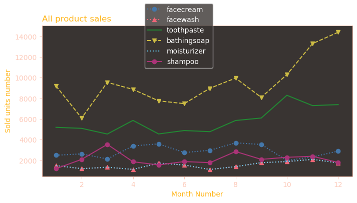

```python
fig, ax = plt.subplots(figsize=[8, 4], dpi=100)

ax.plot(df["month_number"], df["facecream"], label="facecream", ls=":", marker="o")
ax.plot(df["month_number"], df["facewash"], label="facewash", ls=":", marker="^")
ax.plot(df["month_number"], df["toothpaste"], label="toothpaste", ls="-")
ax.plot(df["month_number"], df["bathingsoap"], label="bathingsoap", ls="--", marker="v")
ax.plot(df["month_number"], df["moisturizer"], label="moisturizer", ls=":")
ax.plot(df["month_number"], df["shampoo"], label="shampoo", ls="-", marker="o")

plt.xlabel("Month Number")
plt.ylabel("Sold units number")
plt.title("All product sales", loc="left")

fig.legend(loc="upper center")

plt.show()
```

## 🌸 Exercise 4.

Read toothpaste sales data of each month and show it using a scatter plot

Also, add a grid in the plot. gridline style should “–“.

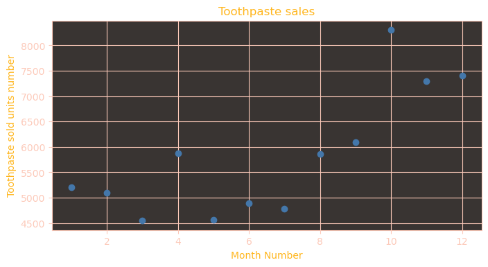

```python
fig, ax = plt.subplots(figsize=[8, 4], dpi=100)

ax.scatter(df["month_number"], df["toothpaste"])

plt.xlabel("Month Number")
plt.ylabel("Toothpaste sold units number")
plt.title("Toothpaste sales")

ax.set_axisbelow(True)
plt.grid(ls="-")

plt.show()
```

## ❄ Exercise 5.

Read face cream and face wash product sales data and show it using the bar chart

The bar chart should display the number of units sold per month for each product. Add a separate bar for each product in the same chart.

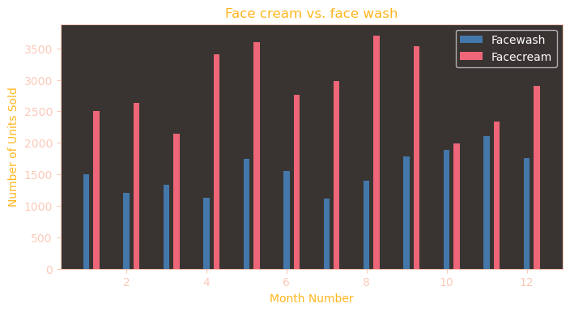

```python
fig, ax = plt.subplots(figsize=[8, 4], dpi=100)

ax.bar(df.month_number, df.facewash, label="Facewash", width=0.15)
ax.bar(df.month_number + 0.25, df.facecream, label="Facecream", width=0.15)
ax.legend(loc="upper right")

plt.xlabel("Month Number")
plt.ylabel("Number of Units Sold")
plt.title("Face cream vs. face wash")

plt.show()
```